# Binomial Distribution Response to Urban Heat - all areas

2025-09-29

```r
library(tidyverse)
library(corrplot)
library(knitr)
library(kableExtra)
library(gghalves)
library(patchwork)
library(scales)
library(glmmTMB)
library(bbmle)
library(DHARMa)
```

# Purpose

The purpose of this page is to summarize an investigation of **tree health categories** as a *categorical* response to urban heat (temperatures).

Response variable: category: *healthy, unhealthy*

# Data Wrangling

```r
data <- read.csv('https://raw.githubusercontent.com/jmhulbert/redhot2/refs/heads/main/data/urban-data-modified.csv')
```

## Remove dead trees

```r
# Remove Dead Trees
data.w.dead <- data
data <- data %>% filter(field.tree.canopy.symptoms!="Tree is dead") %>% filter(field.dieback.percent<100) %>% droplevels()
```

```r
data$binary.tree.canopy.symptoms <- as.factor(data$binary.tree.canopy.symptoms)
levels(data$binary.tree.canopy.symptoms)
```

```
## [1] "Healthy"   "Unhealthy"
```

## Remove observations from Hoyt

```r
data <- data %>% filter(!str_detect(place_guess, "Hoyt") & !str_detect(place_guess, "hoyt"))
```

# Data Visualization

## Binary Tree Condition Categories

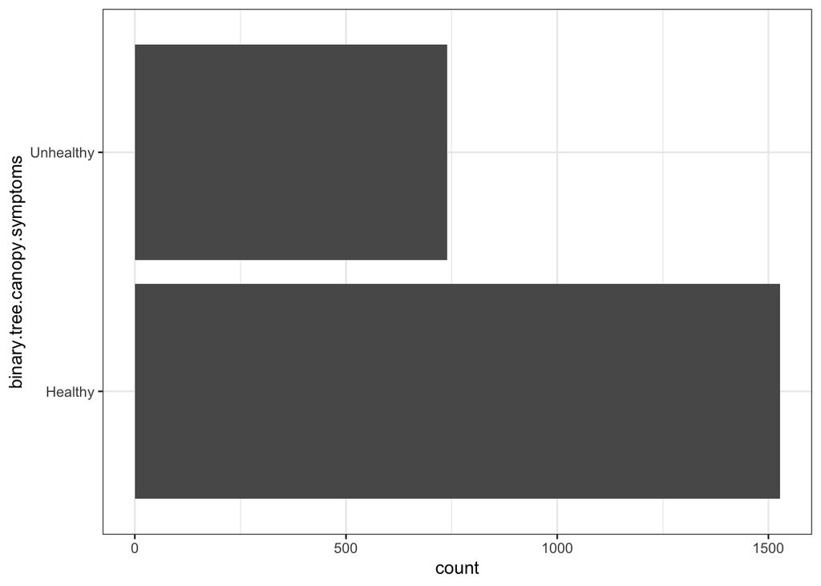

```r
ggplot(data,aes(binary.tree.canopy.symptoms))+geom_histogram(stat="count")+theme_bw()+coord_flip()
```

```r
p1 <-ggplot(data,aes(binary.tree.canopy.symptoms,dist.from.mean.af.c, fill=binary.tree.canopy.symptoms ))+geom_boxplot(alpha=0.5)+theme_bw()+coord_flip() + scale_fill_manual(name="Tree Condition",values=c("#7fcdbb","#fe9929"))+guides(fill=FALSE) +labs(x="Tree Condition",y=NULL)
p2 <-ggplot(data,aes(dist.from.mean.af.c,fill=binary.tree.canopy.symptoms))+geom_density(alpha=0.5) + scale_fill_manual(name="Tree Condition",values=c("#7fcdbb","#fe9929")) +theme_bw() +labs(x="Distance from Mean Afternoon Temperature") +guides(fill=FALSE)
```

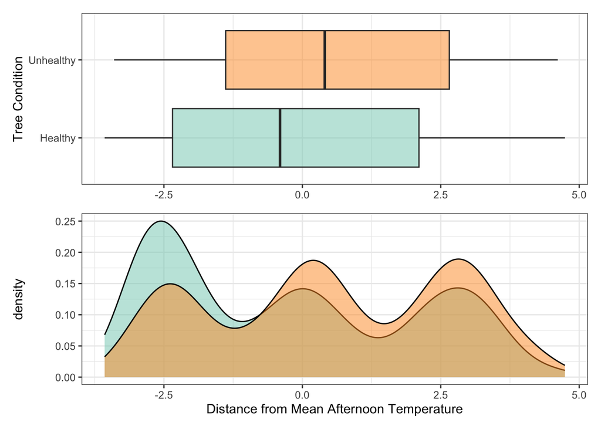

```r
p1 / p2
```

## Reclassified Tree Condition Categories

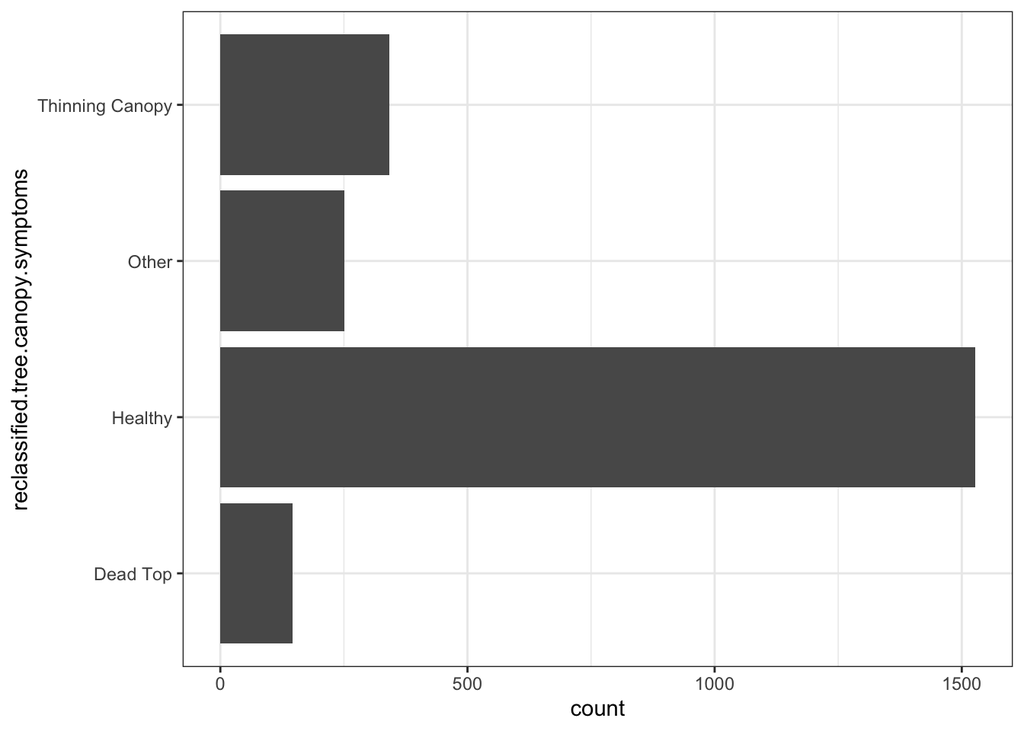

```r
ggplot(data,aes(reclassified.tree.canopy.symptoms))+geom_histogram(stat="count")+theme_bw()+coord_flip()
```

```r
data$top.dieback <- as.factor(data$top.dieback)
data$thinning <- as.factor(data$thinning)
```

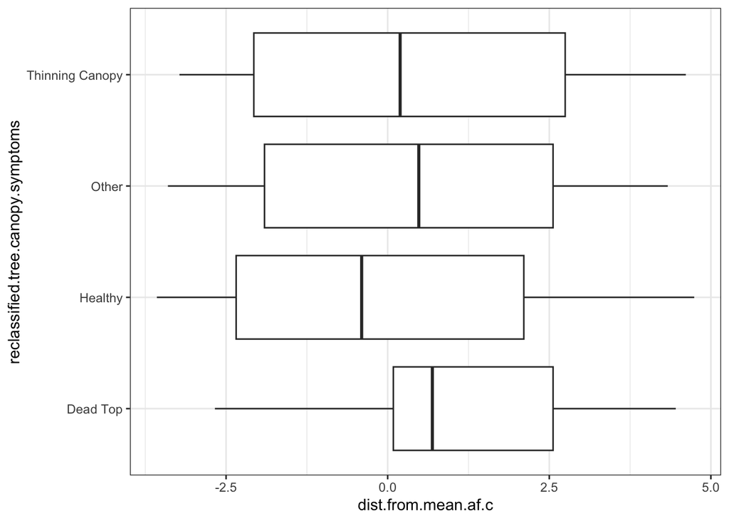

```r
ggplot(data,aes(reclassified.tree.canopy.symptoms,dist.from.mean.af.c ))+geom_boxplot()+theme_bw()+coord_flip()
```

## Temp and Site Type

```r
king <- data %>% filter(Area=="King County")
```

```r
king <- king %>% filter(field.optional...site.type=="Urban"|field.optional...site.type=="Suburban"|field.optional...site.type=="Rural")
```

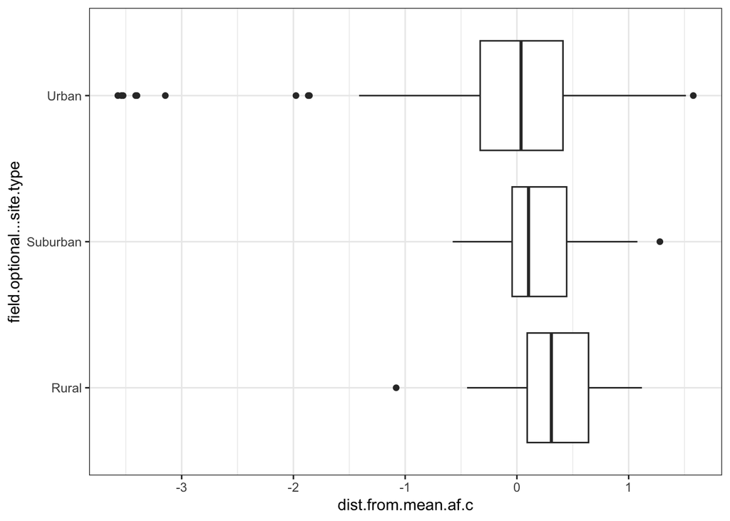

```r
ggplot(king,aes(field.optional...site.type,dist.from.mean.af.c ))+geom_boxplot()+theme_bw()+coord_flip()
```

# Analyses

## Time Series Model Fit

```r
binomial.daily <- glmmTMB(binary.tree.canopy.symptoms ~ dist.from.mean.daily.c + (1|Area),family=binomial,data=data)
binomial.am <- glmmTMB(binary.tree.canopy.symptoms ~ dist.from.mean.am.c + (1|Area),data=data,family=binomial)
binomial.af <- glmmTMB(binary.tree.canopy.symptoms ~ dist.from.mean.af.c + (1|Area),data=data,family=binomial)
binomial.pm <- glmmTMB(binary.tree.canopy.symptoms ~ dist.from.mean.pm.c + (1|Area),data=data,family=binomial)
```

### Compare Time Series Models

```r
AICtab(binomial.daily,binomial.am,binomial.af,binomial.pm)
```

```
##                dAIC df
## binomial.af     0.0 3
## binomial.daily 21.5 3
## binomial.pm    25.6 3
## binomial.am    61.5 3
```

Afternoon heat was the best fit.

## Response 1.0: healthy / unhealthy

```r
#binomial.af <- glmmTMB(binary.tree.canopy.symptoms ~ dist.from.mean.af.c + (1|Area),data=data,family=binomial)
```

### Summary

```r
summary(binomial.af)
```

```
##  Family: binomial  ( logit )
## Formula:
## binary.tree.canopy.symptoms ~ dist.from.mean.af.c + (1 | Area)
## Data: data
##
##       AIC       BIC    logLik -2*log(L)  df.resid
##    2771.8    2789.0   -1382.9    2765.8      2263
##
## Random effects:
##
## Conditional model:
##  Groups Name        Variance Std.Dev.
##  Area   (Intercept) 0.1596   0.3995
## Number of obs: 2266, groups:  Area, 4
##
## Conditional model:
##                     Estimate Std. Error z value Pr(>|z|)
## (Intercept)         -0.70932    0.22048  -3.217  0.00129 **
## dist.from.mean.af.c  0.16379    0.02056   7.967 1.62e-15 ***
## ---
## Signif. codes:  0 '***' 0.001 '**' 0.01 '*' 0.05 '.' 0.1 ' ' 1
```

Tree health is associated with urban heat. The probability of success (tree categorized as unhealthy) increases with urban heat.

Unhealthy trees are considered success (1) because it is the second level (*see levels() output below*). The probability of failure (0) is the first level (Healthy).

```r
levels(data$binary.tree.canopy.symptoms)
```

```
## [1] "Healthy"   "Unhealthy"
```

The probability of a tree being classified as unhealthy increases with urban temperature.

```r
#predict(binomial.af,data[data$DN_AF1=0,])
#predict(binomial.af,DN_AF1=0)
```

### Visualize effects of predictors

First, generate predictions from model

```r
# Create a data frame for predictions
new.data <- expand.grid(
  dist.from.mean.af.c = seq(min(data$dist.from.mean.af.c), max(data$dist.from.mean.af.c), length.out = 100),  # keeping predictor2 constant at its mean
  Area = 0  # assuming random effect is zero for prediction
)
```

```r
new.data$predicted_response <- predict(binomial.af, newdata = new.data, type = "response")
```

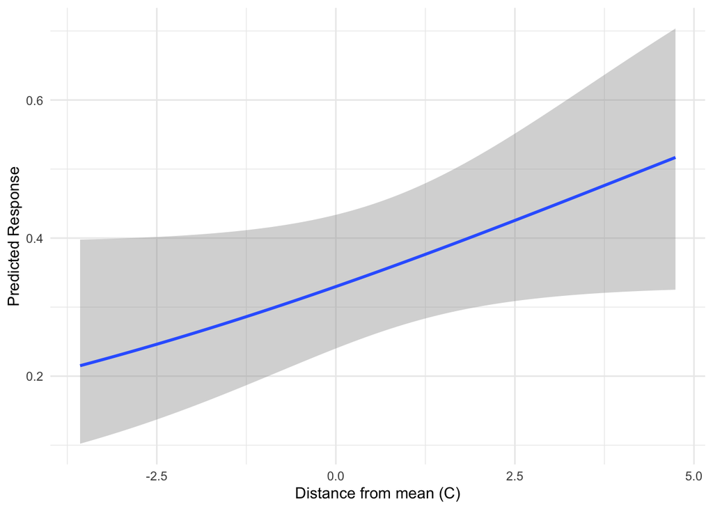

```r
p1 <- ggplot(new.data, aes(x = dist.from.mean.af.c, y = predicted_response)) +
  geom_smooth(method = "glm", method.args = list(family = "binomial")) +
  labs(x = "Distance from mean (C)", y = "Predicted Response") + theme_minimal()
p1
```

```r
# Create a data frame for predictions
new.data.2.inf <- expand.grid(
  dist.from.mean.af.c = seq(min(data$dist.from.mean.af.c), max(100), length.out = 1000), Area = 0)  # keeping predictor2 constant at its mean
```

```r
new.data.2.inf$predicted_response <- predict(binomial.af, newdata = new.data.2.inf, type = "response")
```

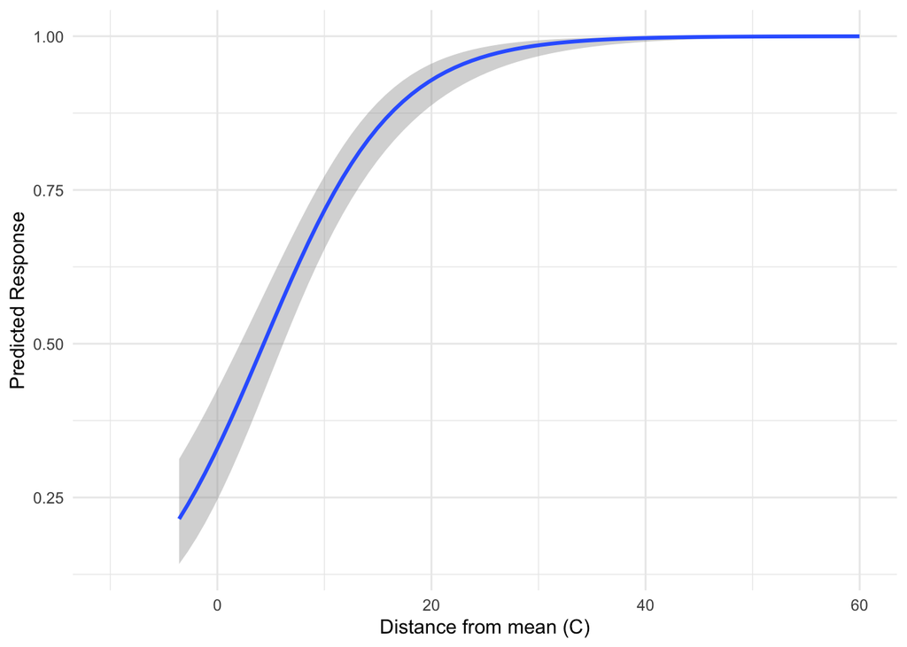

```r
p2 <- ggplot(new.data.2.inf, aes(x = dist.from.mean.af.c, y = predicted_response)) +geom_smooth(method = "glm", method.args = list(family = "binomial")) + labs(x = "Distance from mean (C)", y = "Predicted Response") + scale_x_continuous(limits = c(-10, 60)) +theme_minimal()
p2
```

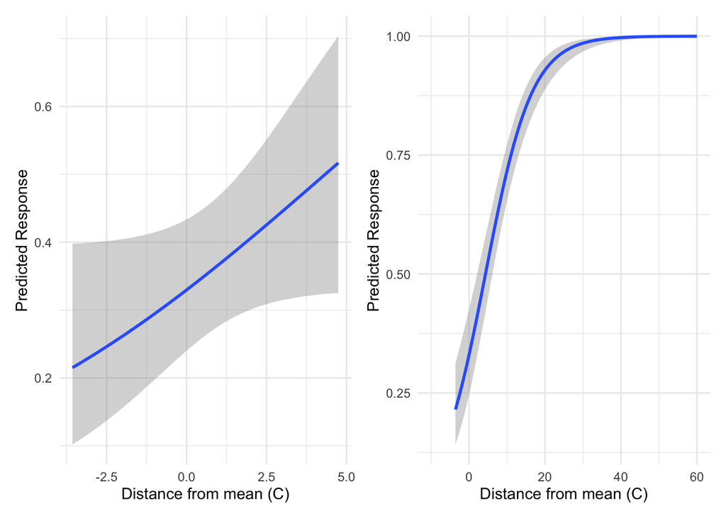

```r
p1 + p2
```

### Probabilities based on predictions

#### Probability when standardized temperature value is -2

```r
new_data <- data.frame(dist.from.mean.af.c = -2,Area=0)
predicted_response <- predict(binomial.af, newdata = new_data, type = "response")
print(predicted_response)
```

```
## [1] 0.2617484
```

Not sure how to intrepret this. There is still a 0.26 probability of being categorized as unhealthy at -2C?

#### Probability when standardized temperature value is 0

```r
new_data <- data.frame(dist.from.mean.af.c = 0,Area=0)
predicted_response <- predict(binomial.af, newdata = new_data, type = "response")
print(predicted_response)
```

```
## [1] 0.3297481
```

The probability of being categorized as unhealthy is 0.33 at the mean temperature.

#### Probability when standardized temperature value is 2

```r
new_data <- data.frame(dist.from.mean.af.c = 2,Area=0)
predicted_response <- predict(binomial.af, newdata = new_data, type = "response")
print(predicted_response)
```

```
## [1] 0.4057053
```

**The probability of tree being classified as unhealthy increases with distance from mean af**

## Response 2.0: healthy / top-dieback

```r
data.top <- data %>% filter(reclassified.tree.canopy.symptoms=="Healthy"|reclassified.tree.canopy.symptoms=="Dead Top") %>% droplevels()
```

```r
top.dieback.binomial.af <- glmmTMB(top.dieback ~ dist.from.mean.af.c + (1|Area),data=data.top,family=binomial)
```

### Summary

```r
summary(top.dieback.binomial.af)
```

```
##  Family: binomial  ( logit )
## Formula:          top.dieback ~ dist.from.mean.af.c + (1 | Area)
## Data: data.top
##
##       AIC       BIC    logLik -2*log(L)  df.resid
##     864.9     881.1    -429.4     858.9      1670
##
## Random effects:
##
## Conditional model:
##  Groups Name        Variance Std.Dev.
##  Area   (Intercept) 1.324    1.151
## Number of obs: 1673, groups:  Area, 4
##
## Conditional model:
##                     Estimate Std. Error z value Pr(>|z|)
## (Intercept)         -2.20523    0.59554  -3.703 0.000213 ***
## dist.from.mean.af.c  0.47305    0.06449   7.336 2.21e-13 ***
## ---
## Signif. codes:  0 '***' 0.001 '**' 0.01 '*' 0.05 '.' 0.1 ' ' 1
```

Tree health is associated with urban heat. The probability of success (tree categorized as having a dead top) increases with urban heat.

Trees having a dead top is considered success (1) because it is the second level (*see levels() output below*). The probability of failure (0) is the first level (Healthy / no top dieback).

```r
levels(data$top.dieback)
```

```
## [1] "No"  "Yes"
```

```r
p3 <-ggplot(data,aes(top.dieback,dist.from.mean.af.c, fill=top.dieback ))+geom_boxplot(alpha=0.5)+theme_bw()+coord_flip() + scale_fill_manual(name="Top Dieback",values=c("#7fcdbb","#fe9929"))+guides(fill=FALSE) +labs(x="Top Dieback",y=NULL)
```

```r
p4 <-ggplot(data,aes(dist.from.mean.af.c,fill=top.dieback))+geom_density(alpha=0.5) + scale_fill_manual(name="Top Dieback",values=c("#7fcdbb","#fe9929")) +theme_bw() +labs(x="Distance from Mean Afternoon Temperature") +guides(fill=FALSE)
```

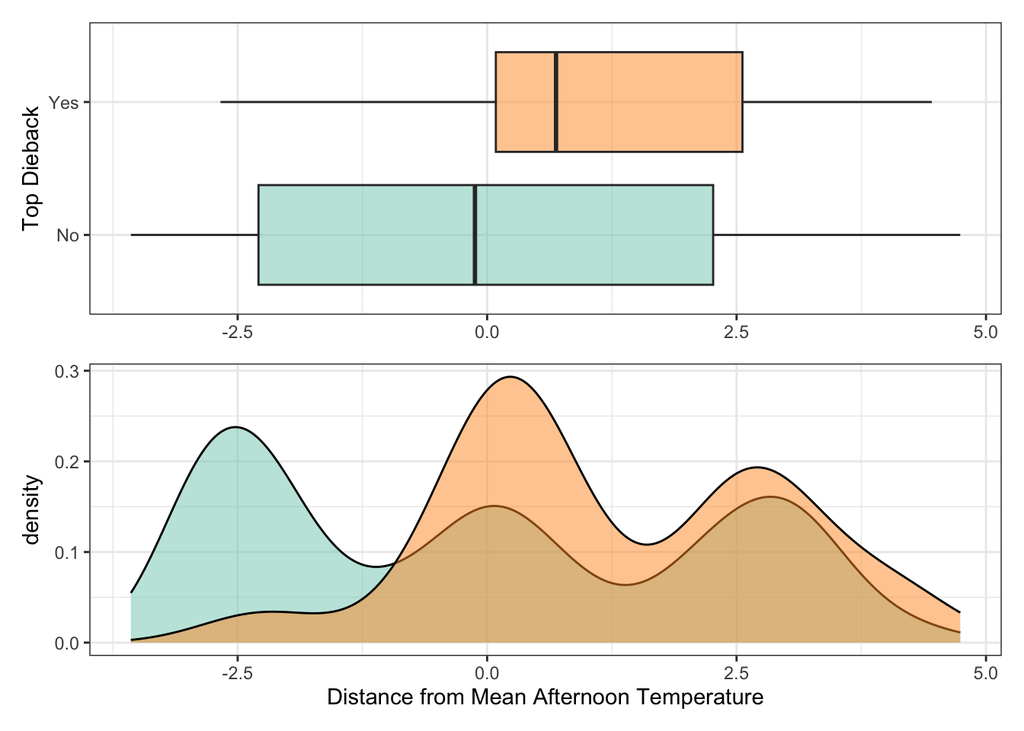

```r
p3 / p4
```

**The probability of a tree having top dieback increases with urban temperature.**

### Visualize effects of predictors

```r
# Create a data frame for predictions
new.data.2 <- expand.grid(
  dist.from.mean.af.c = seq(min(data$dist.from.mean.af.c), max(data$dist.from.mean.af.c), length.out = 100),  # keeping predictor2 constant at its mean
  Area = 0  # assuming random effect is zero for prediction
)
```

```r
new.data.2$predicted_response <- predict(top.dieback.binomial.af, newdata = new.data.2, type = "response")
```

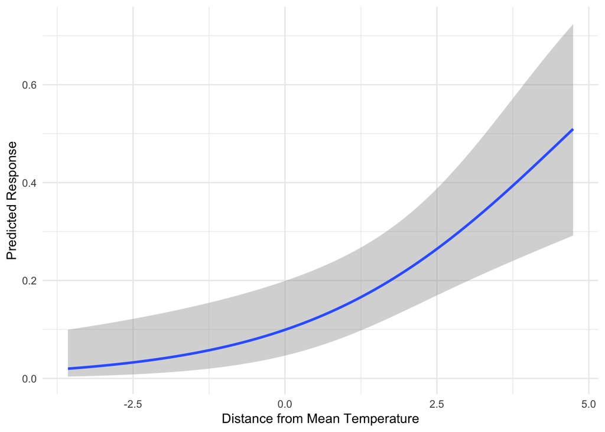

```r
ggplot(new.data.2, aes(x = dist.from.mean.af.c, y = predicted_response)) +
 geom_smooth(method = "glm", method.args = list(family = "binomial")) +
  labs(x = "Distance from Mean Temperature", y = "Predicted Response") +
  theme_minimal()
```

### Probabilities based on predictions

#### Probability when standardized temperature (dist from mean) value is 0

```r
new_data <- data.frame(dist.from.mean.af.c = 0,Area=0)
predicted_response <- predict(top.dieback.binomial.af, newdata = new_data, type = "response")
print(predicted_response)
```

```
## [1] 0.09928159
```

#### Probability when standardized temperature (dist from mean) value is 2

```r
new_data <- data.frame(dist.from.mean.af.c = 2,Area=0)
predicted_response <- predict(top.dieback.binomial.af, newdata = new_data, type = "response")
print(predicted_response)
```

```
## [1] 0.2211234
```

## Response 3.0: healthy / thinning

```r
data.thin <- data %>% filter(reclassified.tree.canopy.symptoms=="Healthy"|reclassified.tree.canopy.symptoms=="Thinning Canopy") %>% droplevels()
```

```r
thinning.binomial.af <- glmmTMB(thinning ~ dist.from.mean.af.c + (1|Area),data=data.thin,family=binomial)
```

### Summary

```r
summary(thinning.binomial.af)
```

```
##  Family: binomial  ( logit )
## Formula:          thinning ~ dist.from.mean.af.c + (1 | Area)
## Data: data.thin
##
##       AIC       BIC    logLik -2*log(L)  df.resid
##    1755.3    1771.9    -874.6    1749.3      1866
##
## Random effects:
##
## Conditional model:
##  Groups Name        Variance Std.Dev.
##  Area   (Intercept) 0.1608   0.401
## Number of obs: 1869, groups:  Area, 4
##
## Conditional model:
##                     Estimate Std. Error z value Pr(>|z|)
## (Intercept)         -1.65493    0.24248  -6.825 8.79e-12 ***
## dist.from.mean.af.c  0.11285    0.02637   4.280 1.87e-05 ***
## ---
## Signif. codes:  0 '***' 0.001 '**' 0.01 '*' 0.05 '.' 0.1 ' ' 1
```

Tree health is associated with urban heat. The probability of success (tree categorized as unhealthy) increases with urban heat

Unhealthy trees are considered success (1) because it is the second level. The probability of failure (0) is the first level (Healthy).

```r
levels(data$thinning)
```

```
## [1] "No"  "Yes"
```

The probability of a tree being classified as unhealthy increases with urban temperature.

### Visualize effects of predictors

First, generate predictions from model

```r
# Create a data frame for predictions
new.data.3 <- expand.grid(
  dist.from.mean.af.c = seq(min(data$dist.from.mean.af.c), max(data$dist.from.mean.af.c), length.out = 100),  # keeping predictor2 constant at its mean
  Area = 0  # assuming random effect is zero for prediction
)
```

```r
new.data.3$predicted_response <- predict(thinning.binomial.af, newdata = new.data.3, type = "response")
```

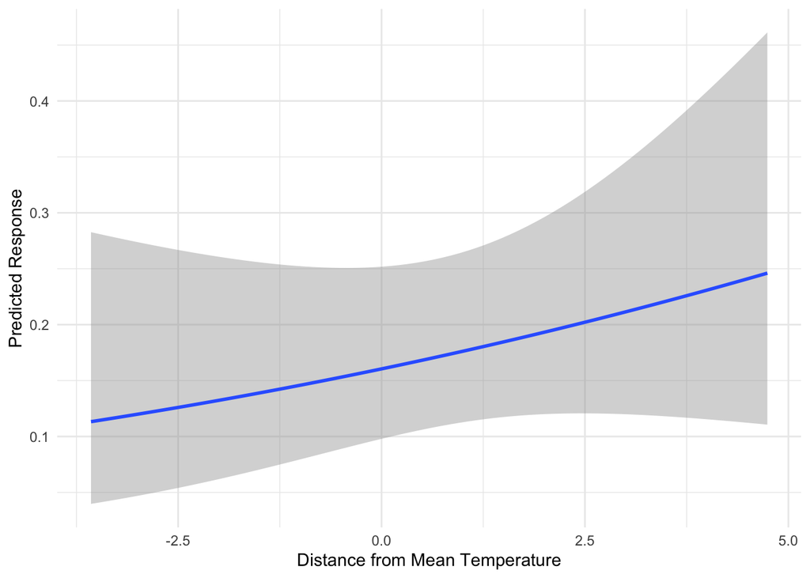

```r
ggplot(new.data.3, aes(x = dist.from.mean.af.c, y = predicted_response)) +
 geom_smooth(method = "glm", method.args = list(family = "binomial")) +
  labs(x = "Distance from Mean Temperature", y = "Predicted Response") +
  theme_minimal()
```

### Compare models

#### Odds Ratios

Unhealthy Trees

```r
# Unhealthy Overall
coef(binomial.af)
```

```
## $Area
##               (Intercept) dist.from.mean.af.c
## King County    -0.2800405           0.1637881
## Pierce County  -0.4821119           0.1637881
## Portland       -1.2371797           0.1637881
## Tacoma         -0.8289372           0.1637881
```

```r
exp(0.1644819)
```

```
## [1] 1.178782
```

Top Dieback

```r
# Top Dieback
coef(top.dieback.binomial.af)
```

```
## $Area
##               (Intercept) dist.from.mean.af.c
## King County    -1.4874138           0.4730505
## Pierce County  -0.7241064           0.4730505
## Portland       -3.1382905           0.4730505
## Tacoma         -3.4128933           0.4730505
```

```r
exp(0.4660774)
```

```
## [1] 1.59373
```

Thinning

```r
# Thinning
coef(thinning.binomial.af)
```

```
## $Area
##               (Intercept) dist.from.mean.af.c
## King County     -1.189092           0.1128516
## Pierce County   -1.838403           0.1128516
## Portland        -2.084128           0.1128516
## Tacoma          -1.484178           0.1128516
```

```r
exp(0.1195909)
```

```
## [1] 1.127036
```

> “An odds ratio greater than 1 implies that the predictor increases the odds of the outcome.”

Heat had the largest effect on predicting if trees had top dieback

## Models with Co-Factors

Note the models below were tested on filtered data. Data categorized as ‘No Selection’, ‘Other’ or blank were filtered out.

### Co-Factor Model 1: adding size

#### Visualize co-factor

```r
data.size.filter <- data %>% filter(tree.size.simplified!="" & tree.size.simplified!="No Selection"  & tree.size.simplified!="Other")
levels(as.factor(data.size.filter$tree.size.simplified))
```

```
## [1] "Large"  "Medium" "Small"
```

1107 were removed from the data. 1159 observations were used in below the co-factor model adding size below.

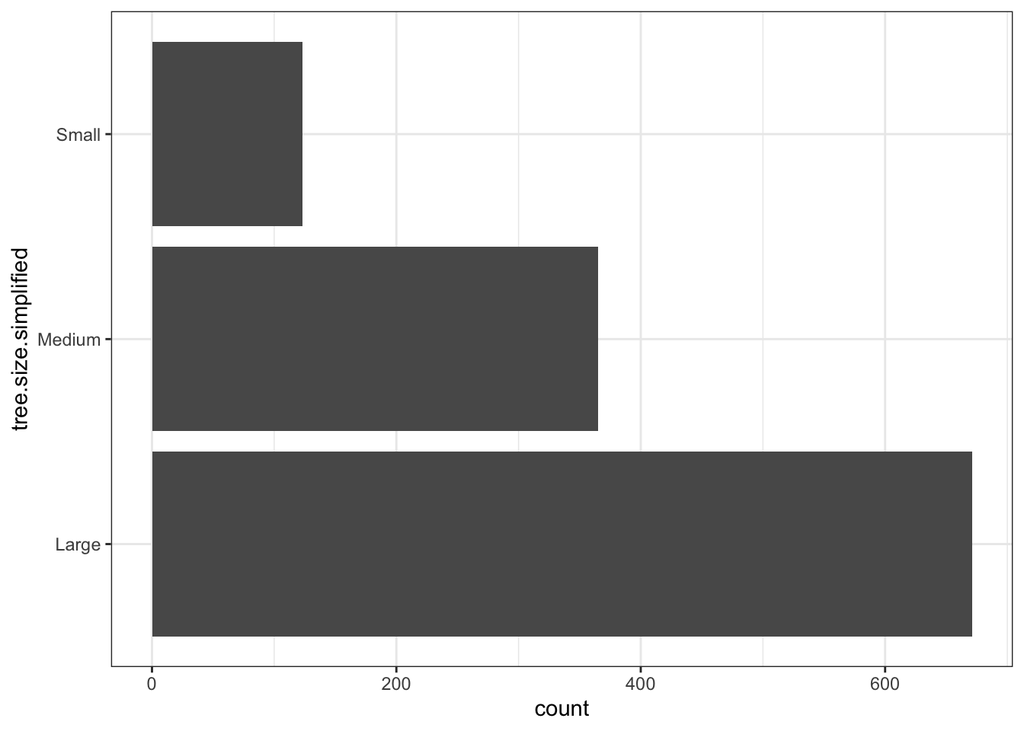

```r
ggplot(data.size.filter,aes(tree.size.simplified))+geom_histogram(stat="count")+coord_flip()+theme_bw()
```

##### All Trees

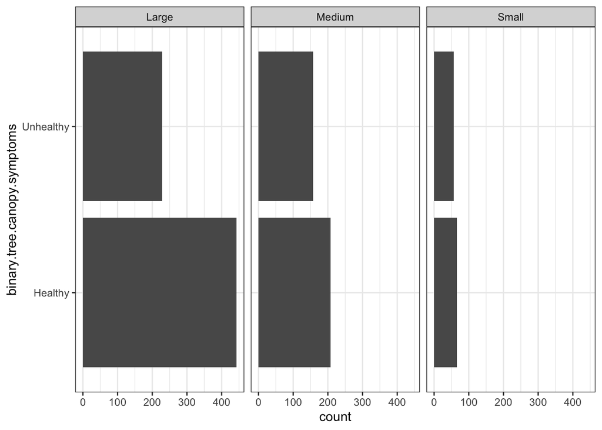

```r
ggplot(data.size.filter,aes(binary.tree.canopy.symptoms)) +facet_wrap(~tree.size.simplified) +geom_histogram(stat="count")+theme_bw()+coord_flip()
```

##### Trees with Dead Tops

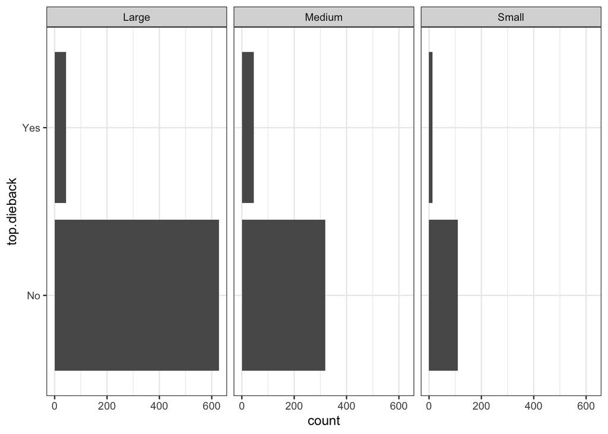

```r
ggplot(data.size.filter,aes(top.dieback)) +facet_wrap(~tree.size.simplified) +geom_histogram(stat="count")+theme_bw()+coord_flip()
```

##### Thinning Trees

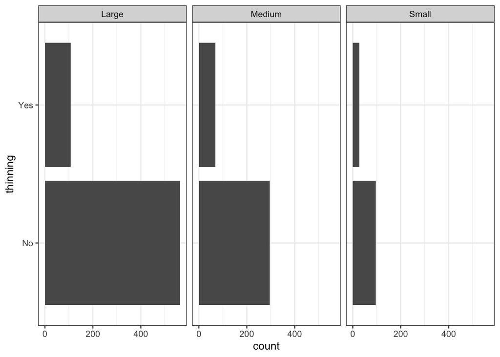

```r
ggplot(data.size.filter,aes(thinning)) +facet_wrap(~tree.size.simplified) +geom_histogram(stat="count")+theme_bw()+coord_flip()
```

#### Response 1.1 healthy / unhealthy

```r
binomial.af.size <- glmmTMB(binary.tree.canopy.symptoms ~ dist.from.mean.af.c +  tree.size.simplified +(1|Area),data=data.size.filter,family=binomial)
```

##### Overall Effect

```r
# Fit the reduced model (without site location description)
reduced_model.binomial.size <- glmmTMB(binary.tree.canopy.symptoms ~ dist.from.mean.af.c + (1 | Area),
                       data = data.size.filter,
                       family = binomial)

# Perform a likelihood ratio test
anova(reduced_model.binomial.size, binomial.af.size, test = "Chisq")
```

```
## Data: data.size.filter
## Models:
## reduced_model.binomial.size: binary.tree.canopy.symptoms ~ dist.from.mean.af.c + (1 | Area), zi=~0, disp=~1
## binomial.af.size: binary.tree.canopy.symptoms ~ dist.from.mean.af.c + tree.size.simplified + , zi=~0, disp=~1
## binomial.af.size:     (1 | Area), zi=~0, disp=~1
##                             Df    AIC    BIC  logLik deviance  Chisq Chi Df
## reduced_model.binomial.size  3 1512.6 1527.7 -753.28   1506.6
## binomial.af.size             5 1509.4 1534.6 -749.68   1499.4 7.1878      2
##                             Pr(>Chisq)
## reduced_model.binomial.size
## binomial.af.size               0.02749 *
## ---
## Signif. codes:  0 '***' 0.001 '**' 0.01 '*' 0.05 '.' 0.1 ' ' 1
```

##### Model Summary

```r
summary(binomial.af.size)
```

```
##  Family: binomial  ( logit )
## Formula:
## binary.tree.canopy.symptoms ~ dist.from.mean.af.c + tree.size.simplified +
##     (1 | Area)
## Data: data.size.filter
##
##       AIC       BIC    logLik -2*log(L)  df.resid
##    1509.4    1534.6    -749.7    1499.4      1154
##
## Random effects:
##
## Conditional model:
##  Groups Name        Variance Std.Dev.
##  Area   (Intercept) 0.1434   0.3786
## Number of obs: 1159, groups:  Area, 4
##
## Conditional model:
##                            Estimate Std. Error z value Pr(>|z|)
## (Intercept)                -0.81340    0.22710  -3.582 0.000341 ***
## dist.from.mean.af.c         0.11346    0.04232   2.681 0.007346 **
## tree.size.simplifiedMedium  0.31736    0.13657   2.324 0.020139 *
## tree.size.simplifiedSmall   0.38578    0.20272   1.903 0.057037 .
## ---
## Signif. codes:  0 '***' 0.001 '**' 0.01 '*' 0.05 '.' 0.1 ' ' 1
```

#### Response 2.1 healthy / top-dieback

```r
data.top.size <- data.size.filter %>% filter(reclassified.tree.canopy.symptoms=="Healthy"|reclassified.tree.canopy.symptoms=="Dead Top") %>% droplevels()
```

```r
top.dieback.binomial.af.size <- glmmTMB(top.dieback ~ dist.from.mean.af.c + tree.size.simplified + (1|Area),data=data.top.size,family=binomial)
```

##### Overall Effect

```r
# Fit the reduced model (without site location description)
reduced_model.top.size <- glmmTMB(top.dieback ~ dist.from.mean.af.c + (1 | Area),
                       data = data.top.size,
                       family = binomial)

# Perform a likelihood ratio test
anova(reduced_model.top.size, top.dieback.binomial.af.size, test = "Chisq")
```

```
## Data: data.top.size
## Models:
## reduced_model.top.size: top.dieback ~ dist.from.mean.af.c + (1 | Area), zi=~0, disp=~1
## top.dieback.binomial.af.size: top.dieback ~ dist.from.mean.af.c + tree.size.simplified + (1 | , zi=~0, disp=~1
## top.dieback.binomial.af.size:     Area), zi=~0, disp=~1
##                              Df    AIC    BIC  logLik deviance  Chisq Chi Df
## reduced_model.top.size        3 605.66 619.79 -299.83   599.66
## top.dieback.binomial.af.size  5 599.28 622.82 -294.64   589.28 10.384      2
##                              Pr(>Chisq)
## reduced_model.top.size
## top.dieback.binomial.af.size    0.00556 **
## ---
## Signif. codes:  0 '***' 0.001 '**' 0.01 '*' 0.05 '.' 0.1 ' ' 1
```

##### Model Summary

```r
summary(top.dieback.binomial.af.size)
```

```
##  Family: binomial  ( logit )
## Formula:
## top.dieback ~ dist.from.mean.af.c + tree.size.simplified + (1 |      Area)
## Data: data.top.size
##
##       AIC       BIC    logLik -2*log(L)  df.resid
##     599.3     622.8    -294.6     589.3       815
##
## Random effects:
##
## Conditional model:
##  Groups Name        Variance Std.Dev.
##  Area   (Intercept) 0.495    0.7036
## Number of obs: 820, groups:  Area, 4
##
## Conditional model:
##                            Estimate Std. Error z value Pr(>|z|)
## (Intercept)                -2.39607    0.41914  -5.717 1.09e-08 ***
## dist.from.mean.af.c         0.20331    0.08992   2.261  0.02376 *
## tree.size.simplifiedMedium  0.73581    0.23193   3.173  0.00151 **
## tree.size.simplifiedSmall   0.53151    0.34817   1.527  0.12687
## ---
## Signif. codes:  0 '***' 0.001 '**' 0.01 '*' 0.05 '.' 0.1 ' ' 1
```

#### Response 3.1 healthy / thinning

```r
data.thin.size <- data.size.filter %>% filter(reclassified.tree.canopy.symptoms=="Healthy"|reclassified.tree.canopy.symptoms=="Thinning Canopy") %>% droplevels()
```

```r
thinning.binomial.af.size <- glmmTMB(thinning ~ dist.from.mean.af.c + tree.size.simplified + (1|Area),data=data.thin.size,family=binomial)
```

##### Overall Effect

```r
# Fit the reduced model (without site location description)
reduced_model.thin.size <- glmmTMB(thinning ~ dist.from.mean.af.c + (1 | Area),
                       data = data.thin.size,
                       family = binomial)

# Perform a likelihood ratio test
anova(reduced_model.thin.size, thinning.binomial.af.size, test = "Chisq")
```

```
## Data: data.thin.size
## Models:
## reduced_model.thin.size: thinning ~ dist.from.mean.af.c + (1 | Area), zi=~0, disp=~1
## thinning.binomial.af.size: thinning ~ dist.from.mean.af.c + tree.size.simplified + (1 | , zi=~0, disp=~1
## thinning.binomial.af.size:     Area), zi=~0, disp=~1
##                           Df    AIC    BIC  logLik deviance  Chisq Chi Df
## reduced_model.thin.size    3 959.13 973.60 -476.56   953.13
## thinning.binomial.af.size  5 960.24 984.37 -475.12   950.24 2.8814      2
##                           Pr(>Chisq)
## reduced_model.thin.size
## thinning.binomial.af.size     0.2368
```

##### Model Summary

```r
summary(thinning.binomial.af.size)
```

```
##  Family: binomial  ( logit )
## Formula:          thinning ~ dist.from.mean.af.c + tree.size.simplified + (1 |
##     Area)
## Data: data.thin.size
##
##       AIC       BIC    logLik -2*log(L)  df.resid
##     960.2     984.4    -475.1     950.2       916
##
## Random effects:
##
## Conditional model:
##  Groups Name        Variance Std.Dev.
##  Area   (Intercept) 0.2791   0.5283
## Number of obs: 921, groups:  Area, 4
##
## Conditional model:
##                            Estimate Std. Error z value Pr(>|z|)
## (Intercept)                -1.63755    0.33588  -4.875 1.09e-06 ***
## dist.from.mean.af.c         0.04269    0.05534   0.771    0.441
## tree.size.simplifiedMedium  0.22714    0.17926   1.267    0.205
## tree.size.simplifiedSmall   0.37121    0.25737   1.442    0.149
## ---
## Signif. codes:  0 '***' 0.001 '**' 0.01 '*' 0.05 '.' 0.1 ' ' 1
```

### Co-Factor Model 2: adding location

#### Visualize co-factor

```r
data.site.filter <- data %>% filter(field.optional...site.location.description!="" & field.optional...site.location.description!="No Selection" & field.optional...site.location.description!="Other" & field.optional...site.location.description!="Not Sure") %>% droplevels()
levels(as.factor(data.site.filter$field.optional...site.location.description))
```

```
## [1] "Forest edge"                     "Inside a forest canopy"
## [3] "Roadside"                        "Urban yard or open park grounds"
```

1309 were removed from the data. 957 observations were used in below the co-factor model adding size below.

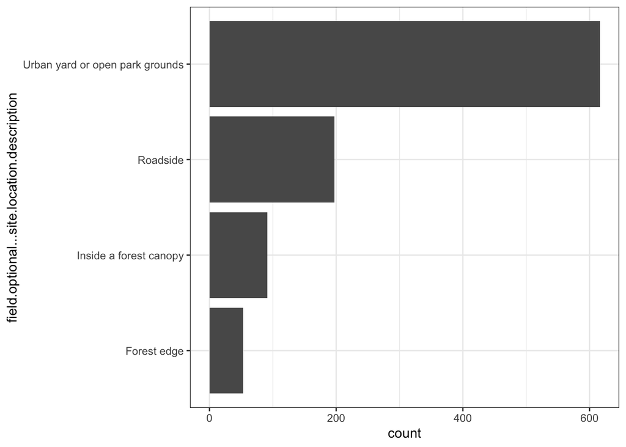

```r
ggplot(data.site.filter,aes(field.optional...site.location.description))+geom_histogram(stat="count")+coord_flip()+theme_bw()
```

##### All Trees

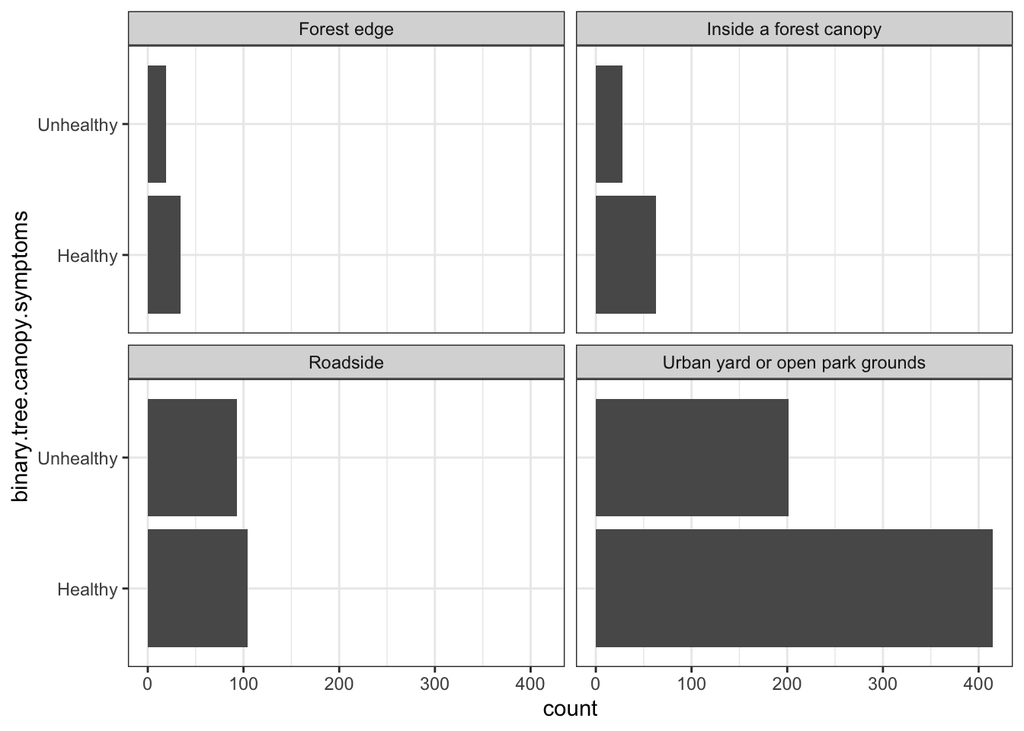

```r
ggplot(data.site.filter,aes(binary.tree.canopy.symptoms)) +facet_wrap(~field.optional...site.location.description) +geom_histogram(stat="count")+theme_bw()+coord_flip()
```

##### Trees with Dead Tops

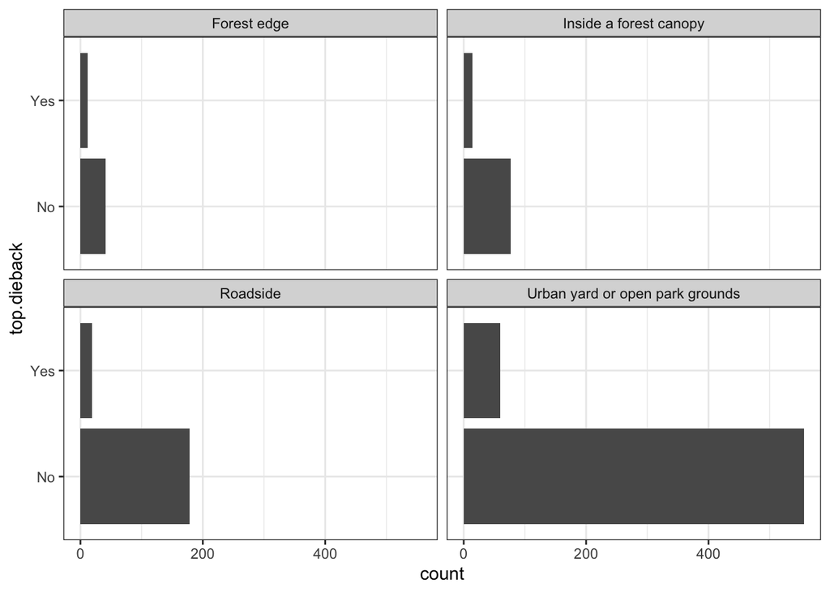

```r
ggplot(data.site.filter,aes(top.dieback)) +facet_wrap(~field.optional...site.location.description) +geom_histogram(stat="count")+theme_bw()+coord_flip()
```

##### Thinning Trees

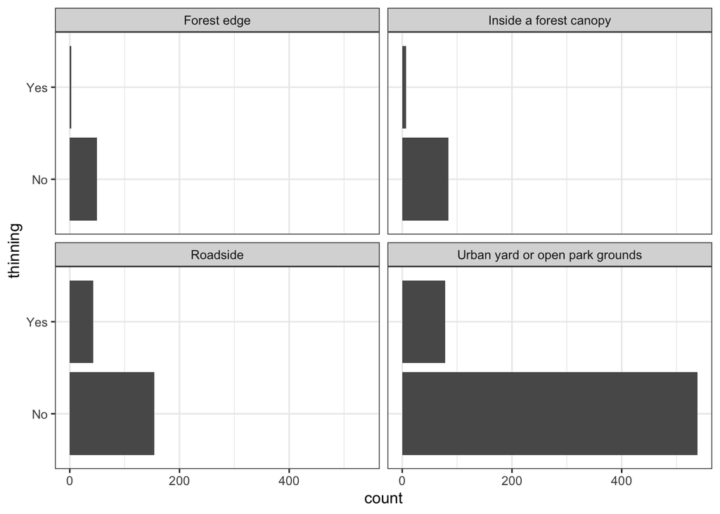

```r
ggplot(data.site.filter,aes(thinning)) +facet_wrap(~field.optional...site.location.description) +geom_histogram(stat="count")+theme_bw()+coord_flip()
```

#### Response 1.2 healthy / unhealthy

```r
data.site.filter$field.optional...site.location.description <- as.factor(data.site.filter$field.optional...site.location.description)

data.site.filter$field.optional...site.location.description <- relevel(data.site.filter$field.optional...site.location.description, ref = "Inside a forest canopy")
```

```r
binomial.af.site <- glmmTMB(binary.tree.canopy.symptoms ~ dist.from.mean.af.c + field.optional...site.location.description  + (1|Area),data=data.site.filter,family=binomial)
```

##### Overall Effect

```r
# Fit the reduced model (without site location description)
reduced_model.binomial.site <- glmmTMB(binary.tree.canopy.symptoms ~ dist.from.mean.af.c + (1 | Area),
                       data = data.site.filter,
                       family = binomial)

# Perform a likelihood ratio test
anova(reduced_model.binomial.site, binomial.af.site, test = "Chisq")
```

```
## Data: data.site.filter
## Models:
## reduced_model.binomial.site: binary.tree.canopy.symptoms ~ dist.from.mean.af.c + (1 | Area), zi=~0, disp=~1
## binomial.af.site: binary.tree.canopy.symptoms ~ dist.from.mean.af.c + field.optional...site.location.description + , zi=~0, disp=~1
## binomial.af.site:     (1 | Area), zi=~0, disp=~1
##                             Df    AIC    BIC  logLik deviance  Chisq Chi Df
## reduced_model.binomial.site  3 1213.8 1228.4 -603.90   1207.8
## binomial.af.site             6 1209.1 1238.3 -598.55   1197.1 10.688      3
##                             Pr(>Chisq)
## reduced_model.binomial.site
## binomial.af.site               0.01354 *
## ---
## Signif. codes:  0 '***' 0.001 '**' 0.01 '*' 0.05 '.' 0.1 ' ' 1
```

The inclusion of the site variable improves the model fit, implying that the site location descriptions have a meaningful and statistically significant impact on the binary outcome binary.tree.canopy.symptoms.

##### Model Summary

```r
summary(binomial.af.site)
```

```
##  Family: binomial  ( logit )
## Formula:
## binary.tree.canopy.symptoms ~ dist.from.mean.af.c + field.optional...site.location.description +
##     (1 | Area)
## Data: data.site.filter
##
##       AIC       BIC    logLik -2*log(L)  df.resid
##    1209.1    1238.3    -598.6    1197.1       951
##
## Random effects:
##
## Conditional model:
##  Groups Name        Variance Std.Dev.
##  Area   (Intercept) 0.174    0.4171
## Number of obs: 957, groups:  Area, 4
##
## Conditional model:
##                                                                           Estimate
## (Intercept)                                                               -0.94018
## dist.from.mean.af.c                                                        0.18500
## field.optional...site.location.descriptionForest edge                      0.40869
## field.optional...site.location.descriptionRoadside                         0.57339
## field.optional...site.location.descriptionUrban yard or open park grounds  0.02047
##                                                                           Std. Error
## (Intercept)                                                                  0.32772
## dist.from.mean.af.c                                                          0.05955
## field.optional...site.location.descriptionForest edge                        0.38085
## field.optional...site.location.descriptionRoadside                           0.27801
## field.optional...site.location.descriptionUrban yard or open park grounds    0.26313
##                                                                           z value
## (Intercept)                                                                -2.869
## dist.from.mean.af.c                                                         3.107
## field.optional...site.location.descriptionForest edge                       1.073
## field.optional...site.location.descriptionRoadside                          2.062
## field.optional...site.location.descriptionUrban yard or open park grounds   0.078
##                                                                           Pr(>|z|)
## (Intercept)                                                                0.00412
## dist.from.mean.af.c                                                        0.00189
## field.optional...site.location.descriptionForest edge                      0.28322
## field.optional...site.location.descriptionRoadside                         0.03916
## field.optional...site.location.descriptionUrban yard or open park grounds  0.93799
##
## (Intercept)                                                               **
## dist.from.mean.af.c                                                       **
## field.optional...site.location.descriptionForest edge
## field.optional...site.location.descriptionRoadside                        *
## field.optional...site.location.descriptionUrban yard or open park grounds
## ---
## Signif. codes:  0 '***' 0.001 '**' 0.01 '*' 0.05 '.' 0.1 ' ' 1
```

#### Response 2.2 healthy / top-dieback

```r
data.top.site <- data.site.filter %>% filter(reclassified.tree.canopy.symptoms=="Healthy"|reclassified.tree.canopy.symptoms=="Dead Top") %>% droplevels()
```

```r
data.top.site$field.optional...site.location.description <- as.factor(data.top.site$field.optional...site.location.description)

data.top.site$field.optional...site.location.description <- relevel(data.top.site$field.optional...site.location.description, ref = "Inside a forest canopy")
```

```r
top.dieback.binomial.af.site <- glmmTMB(top.dieback ~ dist.from.mean.af.c + field.optional...site.location.description + (1|Area),data=data.top.site,family=binomial)
```

##### Overall Effect

```r
# Fit the reduced model (without site location description)
reduced_model.top.site <- glmmTMB(top.dieback ~ dist.from.mean.af.c + (1 | Area),
                       data = data.top.site,
                       family = binomial)

# Perform a likelihood ratio test
anova(reduced_model.top.site, top.dieback.binomial.af.site, test = "Chisq")
```

```
## Data: data.top.site
## Models:
## reduced_model.top.site: top.dieback ~ dist.from.mean.af.c + (1 | Area), zi=~0, disp=~1
## top.dieback.binomial.af.site: top.dieback ~ dist.from.mean.af.c + field.optional...site.location.description + , zi=~0, disp=~1
## top.dieback.binomial.af.site:     (1 | Area), zi=~0, disp=~1
##                              Df    AIC    BIC  logLik deviance Chisq Chi Df
## reduced_model.top.site        3 569.75 583.50 -281.88   563.75
## top.dieback.binomial.af.site  6 568.53 596.02 -278.27   556.53  7.22      3
##                              Pr(>Chisq)
## reduced_model.top.site
## top.dieback.binomial.af.site    0.06521 .
## ---
## Signif. codes:  0 '***' 0.001 '**' 0.01 '*' 0.05 '.' 0.1 ' ' 1
```

The inclusion of the site variable in the model provides a better fit, but the improvement is only marginally significant. This suggests that while site location descriptions may have an effect on top.dieback, the evidence is not strong enough to definitively conclude a significant overall effect at the 0.05 level. Further investigation or additional data might help clarify the importance of this predictor.

##### Model Summary

```r
summary(top.dieback.binomial.af.site)
```

```
##  Family: binomial  ( logit )
## Formula:
## top.dieback ~ dist.from.mean.af.c + field.optional...site.location.description +
##     (1 | Area)
## Data: data.top.site
##
##       AIC       BIC    logLik -2*log(L)  df.resid
##     568.5     596.0    -278.3     556.5       715
##
## Random effects:
##
## Conditional model:
##  Groups Name        Variance Std.Dev.
##  Area   (Intercept) 0.9511   0.9753
## Number of obs: 721, groups:  Area, 4
##
## Conditional model:
##                                                                           Estimate
## (Intercept)                                                                -1.6302
## dist.from.mean.af.c                                                         0.1362
## field.optional...site.location.descriptionForest edge                       0.7516
## field.optional...site.location.descriptionRoadside                         -0.2485
## field.optional...site.location.descriptionUrban yard or open park grounds  -0.3595
##                                                                           Std. Error
## (Intercept)                                                                   0.5963
## dist.from.mean.af.c                                                           0.1090
## field.optional...site.location.descriptionForest edge                         0.4778
## field.optional...site.location.descriptionRoadside                            0.4019
## field.optional...site.location.descriptionUrban yard or open park grounds     0.3584
##                                                                           z value
## (Intercept)                                                                -2.734
## dist.from.mean.af.c                                                         1.249
## field.optional...site.location.descriptionForest edge                       1.573
## field.optional...site.location.descriptionRoadside                         -0.618
## field.optional...site.location.descriptionUrban yard or open park grounds  -1.003
##                                                                           Pr(>|z|)
## (Intercept)                                                                0.00626
## dist.from.mean.af.c                                                        0.21171
## field.optional...site.location.descriptionForest edge                      0.11574
## field.optional...site.location.descriptionRoadside                         0.53640
## field.optional...site.location.descriptionUrban yard or open park grounds  0.31582
##
## (Intercept)                                                               **
## dist.from.mean.af.c
## field.optional...site.location.descriptionForest edge
## field.optional...site.location.descriptionRoadside
## field.optional...site.location.descriptionUrban yard or open park grounds
## ---
## Signif. codes:  0 '***' 0.001 '**' 0.01 '*' 0.05 '.' 0.1 ' ' 1
```

#### Response 3.2 healthy / thinning

```r
data.thin.site <- data.site.filter %>% filter(reclassified.tree.canopy.symptoms=="Healthy"|reclassified.tree.canopy.symptoms=="Thinning Canopy") %>% droplevels()
```

```r
data.thin.site$field.optional...site.location.description <- as.factor(data.thin.site$field.optional...site.location.description)

data.thin.site$field.optional...site.location.description <- relevel(data.thin.site$field.optional...site.location.description, ref = "Inside a forest canopy")
```

```r
thinning.binomial.af.site <- glmmTMB(thinning ~ dist.from.mean.af.c + field.optional...site.location.description + (1|Area),data=data.thin.site,family=binomial)
```

##### Overall Effect

```r
# Fit the reduced model (without site location description)
reduced_model.thin.site <- glmmTMB(thinning ~ dist.from.mean.af.c + (1 | Area),
                       data = data.thin.site,
                       family = binomial)

# Perform a likelihood ratio test
anova(reduced_model.thin.site, thinning.binomial.af.site, test = "Chisq")
```

```
## Data: data.thin.site
## Models:
## reduced_model.thin.site: thinning ~ dist.from.mean.af.c + (1 | Area), zi=~0, disp=~1
## thinning.binomial.af.site: thinning ~ dist.from.mean.af.c + field.optional...site.location.description + , zi=~0, disp=~1
## thinning.binomial.af.site:     (1 | Area), zi=~0, disp=~1
##                           Df    AIC    BIC  logLik deviance  Chisq Chi Df
## reduced_model.thin.site    3 686.23 700.08 -340.12   680.23
## thinning.binomial.af.site  6 677.87 705.57 -332.93   665.87 14.362      3
##                           Pr(>Chisq)
## reduced_model.thin.site
## thinning.binomial.af.site   0.002452 **
## ---
## Signif. codes:  0 '***' 0.001 '**' 0.01 '*' 0.05 '.' 0.1 ' ' 1
```

##### Model Summary

```r
summary(thinning.binomial.af.site)
```

```
##  Family: binomial  ( logit )
## Formula:
## thinning ~ dist.from.mean.af.c + field.optional...site.location.description +
##     (1 | Area)
## Data: data.thin.site
##
##       AIC       BIC    logLik -2*log(L)  df.resid
##     677.9     705.6    -332.9     665.9       741
##
## Random effects:
##
## Conditional model:
##  Groups Name        Variance Std.Dev.
##  Area   (Intercept) 0.09973  0.3158
## Number of obs: 747, groups:  Area, 4
##
## Conditional model:
##                                                                           Estimate
## (Intercept)                                                               -2.29014
## dist.from.mean.af.c                                                        0.12718
## field.optional...site.location.descriptionForest edge                     -0.10874
## field.optional...site.location.descriptionRoadside                         1.16492
## field.optional...site.location.descriptionUrban yard or open park grounds  0.40754
##                                                                           Std. Error
## (Intercept)                                                                  0.44862
## dist.from.mean.af.c                                                          0.07799
## field.optional...site.location.descriptionForest edge                        0.72919
## field.optional...site.location.descriptionRoadside                           0.44576
## field.optional...site.location.descriptionUrban yard or open park grounds    0.43705
##                                                                           z value
## (Intercept)                                                                -5.105
## dist.from.mean.af.c                                                         1.631
## field.optional...site.location.descriptionForest edge                      -0.149
## field.optional...site.location.descriptionRoadside                          2.613
## field.optional...site.location.descriptionUrban yard or open park grounds   0.932
##                                                                           Pr(>|z|)
## (Intercept)                                                               3.31e-07
## dist.from.mean.af.c                                                        0.10297
## field.optional...site.location.descriptionForest edge                      0.88146
## field.optional...site.location.descriptionRoadside                         0.00897
## field.optional...site.location.descriptionUrban yard or open park grounds  0.35109
##
## (Intercept)                                                               ***
## dist.from.mean.af.c
## field.optional...site.location.descriptionForest edge
## field.optional...site.location.descriptionRoadside                        **
## field.optional...site.location.descriptionUrban yard or open park grounds
## ---
## Signif. codes:  0 '***' 0.001 '**' 0.01 '*' 0.05 '.' 0.1 ' ' 1
```

The Roadside location is significantly associated with a higher likelihood of thinning compared to the trees inside a forest canopy. In contrast, Forest edge and Urban yard or open park grounds do not show significant effects on thinning compared to trees inside a forest canopy.